# Analysis of Dual-Colour Ssd1 reporters

Edward Wallace

14/12/2021

# Summary

We set out to test the effect of Ssd1-binding motifs in 5’UTRs on reporter gene translation in wild-type and ∆ssd1 cells. Our reporter was a mTurquoise2 fluorescent protein, detected in the AmCyan channel. We had a fluorescent reference protein mCherry, detected in the PE-Cy5 channel.

These results are analysed by Edward Wallace on 14th December 2021.

### Define functions to load flow cytometry data, using FlowCore package

```r
repair_flow_colnames <- function(string) {
  string %>%
    stringr::str_replace_all(" ", "") %>%
    stringr::str_replace_all("PE-", "PE") %>%
    stringr::str_replace_all("-", "_")
}

read_fcs_tibble <- function(file,...) {
  read.FCS(file,...) %>%
    .@exprs %>%
    as_tibble %>%
    set_names(repair_flow_colnames(names(.)))
}
```

## Pilot analysis comparing one pair of samples, replicate a for tandem motif

```r
datadir <- "/Volumes/biology/groups/wallace_rna/data/2021/12_Dec/Edward/2021-12-14_EW_yeast_mtu2_mch"

flowdata_WT_2_a <- paste(datadir,"Specimen_001__yRB037a_005.fcs", sep = "/") %>%
  read_fcs_tibble

flowdata_dS_2_a <- paste(datadir,"Specimen_001__yRB040a_007.fcs", sep = "/") %>%
  read_fcs_tibble
```

### Plot AmCyan (mTurq2) and (mCherry) separately, as well as the ratio

This shows that the reporter gene expression differs but the reference gene expression is constant.

Note in this analysis we did not gate, we are taking all of the data.

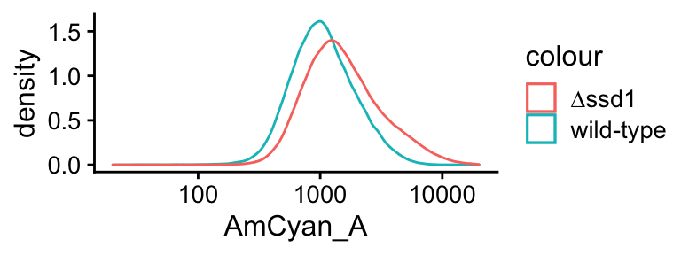

```r
ggplot(data = flowdata_WT_2_a, aes(x = AmCyan_A)) +
  geom_density(data = flowdata_WT_2_a, aes(colour = "wild-type")) +
  geom_density(data = flowdata_dS_2_a, aes(colour = "∆ssd1")) +
  scale_x_log10(limits = c(20, 20000))
```

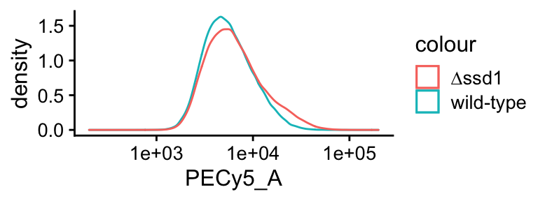

```r
ggplot(data = flowdata_WT_2_a, aes(x = PECy5_A)) +
  geom_density(data = flowdata_WT_2_a, aes(colour = "wild-type")) +
  geom_density(data = flowdata_dS_2_a, aes(colour = "∆ssd1")) +
  scale_x_log10(limits = c(200, 200000))
```

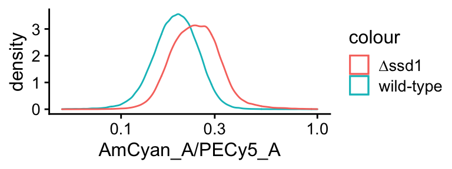

```r
ggplot(data = flowdata_WT_2_a, aes(x = AmCyan_A/PECy5_A)) +
  geom_density(data = flowdata_WT_2_a, aes(colour = "wild-type")) +
  geom_density(data = flowdata_dS_2_a, aes(colour = "∆ssd1")) +
  scale_x_log10(limits = c(0.05,1))
```

### Plot AmCyan (mTurq2) and (mCherry) together

This shows that there is more blue:red in the ∆ssd1 samples in this replicated, as predicted

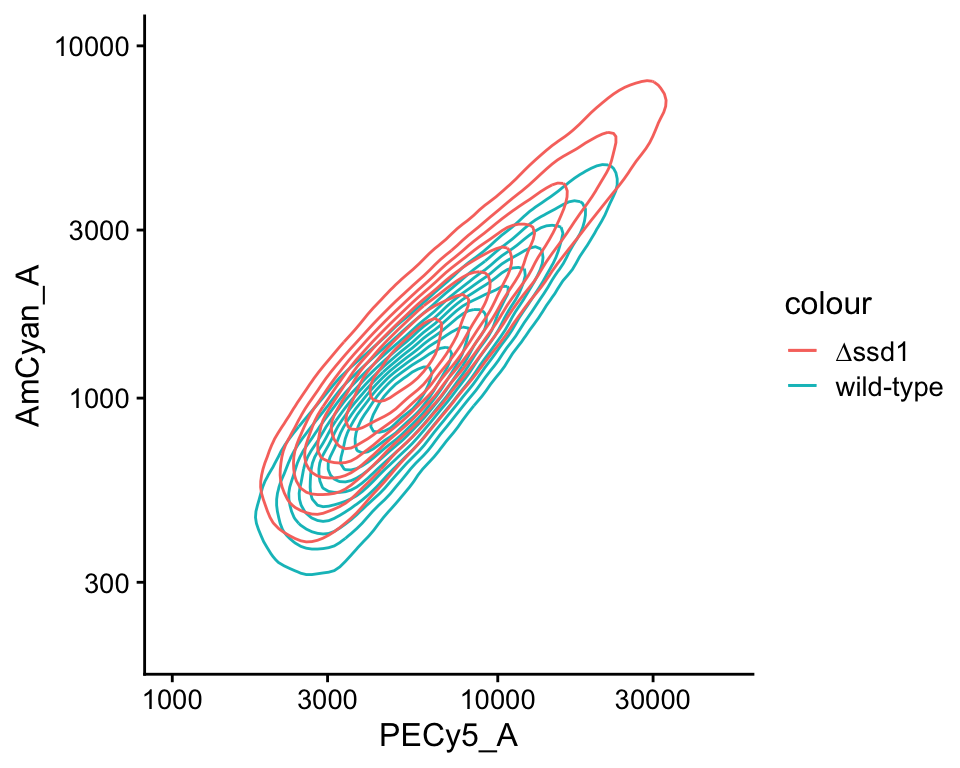

```r
ggplot(data = flowdata_WT_2_a, aes(x = PECy5_A, y = AmCyan_A)) +
  geom_density_2d(data = flowdata_WT_2_a, aes(colour = "wild-type")) +
  geom_density_2d(data = flowdata_dS_2_a, aes(colour = "∆ssd1")) +
  scale_x_log10(limits = c(1000, 50000)) + scale_y_log10(limits = c(200, 10000))
```

## Comparative analysis across all 3 replicates

### Describe the data

First we load the sample sheet, that describes the sample contents and filenames.

```r
datadir <- "/Volumes/biology/groups/wallace_rna/data/2021/12_Dec/Edward/2021-12-14_EW_yeast_mtu2_mch"

samplesheet <- readxl::read_excel("../data/StrainsForFlowCytometry_14_12_2021.xlsx") %>%
  select(SampleLabel, Background, MotifCount, Replicate, Filename) %>%
  mutate(MotifCount = factor(MotifCount, levels = c("0","1","2")),
         Ssd1Status = factor(Background,
                              levels = c("BY4741", "ssd1D"),
                                labels = c("wild-type","∆ssd1")))

samplesheet
```

```
## # A tibble: 22 × 6
##    SampleLabel Background MotifCount Replicate Filename               Ssd1Status
##    <chr>       <chr>      <fct>      <chr>     <chr>                  <fct>
##  1 BY4741o     BY4741     <NA>       o         Specimen_001__BY4741o… wild-type
##  2 yWD010o     BY4741     <NA>       o         Specimen_001__yWD010o… wild-type
##  3 yRB034a     ssd1D      0          a         Specimen_001__yRB034a… ∆ssd1
##  4 yRB034b     ssd1D      0          b         Specimen_001__yRB034b… ∆ssd1
##  5 yRB034c     ssd1D      0          c         Specimen_001__yRB034c… ∆ssd1
##  6 yRB036a     BY4741     0          a         Specimen_001__yRB036a… wild-type
##  7 yRB036b     BY4741     0          b         Specimen_001__yRB036b… wild-type
##  8 yRB036c     BY4741     0          c         Specimen_001__yRB036c… wild-type
##  9 yRB037a     BY4741     2          a         Specimen_001__yRB037a… wild-type
## 10 yRB037b     BY4741     2          b         Specimen_001__yRB037b… wild-type
## # … with 12 more rows
```

### Load all the data

Next we load the data from all those files.

This code chunk takes about 1 minute to run as there is so much data.

```r
flow_data_all <- samplesheet %>%
  group_by(SampleLabel, Ssd1Status, MotifCount, Replicate, Filename) %>%
  do( read_fcs_tibble(paste(datadir, .$Filename[1], sep = "/")) )

flow_data_gated <- flow_data_all %>%
  dplyr::filter(FSC_W > 60000, FSC_W < 100000,
                FSC_A > 35000, FSC_A < 225000)
```

Here, `flow_data_gated` is gated for singlet cells by forward scatter width and area.

## Gated data contain roughly 100,000 singlet cells per sample:

```r
flow_data_all
```

```
## # A tibble: 2,731,271 × 46
## # Groups:   SampleLabel, Ssd1Status, MotifCount, Replicate, Filename [22]
##    SampleLabel Ssd1Status MotifCount Replicate Filename      FSC_A  FSC_H  FSC_W
##    <chr>       <fct>      <fct>      <chr>     <chr>         <dbl>  <dbl>  <dbl>
##  1 BY4741o     wild-type  <NA>       o         Specimen_00… 1.04e5  83829 81014.
##  2 BY4741o     wild-type  <NA>       o         Specimen_00… 2.62e5 260331 65992.
##  3 BY4741o     wild-type  <NA>       o         Specimen_00… 6.94e4  58975 77112.
##  4 BY4741o     wild-type  <NA>       o         Specimen_00… 1.40e5 111943 81874.
##  5 BY4741o     wild-type  <NA>       o         Specimen_00… 9.02e4  72806 81158.
##  6 BY4741o     wild-type  <NA>       o         Specimen_00… 7.21e4  64513 73215.
##  7 BY4741o     wild-type  <NA>       o         Specimen_00… 7.91e4  70428 73640.
##  8 BY4741o     wild-type  <NA>       o         Specimen_00… 7.90e4  64178 80687.
##  9 BY4741o     wild-type  <NA>       o         Specimen_00… 8.32e4  60186 90570.
## 10 BY4741o     wild-type  <NA>       o         Specimen_00… 1.60e5 117303 89294.
## # … with 2,731,261 more rows, and 38 more variables: SSC_A <dbl>, SSC_H <dbl>,
## #   SSC_W <dbl>, FITC_A <dbl>, FITC_H <dbl>, FITC_W <dbl>, PerCP_Cy5_5_A <dbl>,
## #   PerCP_Cy5_5_H <dbl>, APC_A <dbl>, APC_H <dbl>, AlexaFluor700_A <dbl>,
## #   AlexaFluor700_H <dbl>, APC_Cy7_A <dbl>, APC_Cy7_H <dbl>, BV421_A <dbl>,
## #   BV421_H <dbl>, BV421_W <dbl>, AmCyan_A <dbl>, AmCyan_H <dbl>,
## #   BV605_A <dbl>, BV605_H <dbl>, BV650_A <dbl>, BV650_H <dbl>, BV711_A <dbl>,
## #   BV711_H <dbl>, BV786_A <dbl>, BV786_H <dbl>, PEA <dbl>, PEH <dbl>, …
```

```r
left_join(flow_data_all %>%
            group_by(SampleLabel) %>%
            tally(),
          flow_data_gated %>%
            group_by(SampleLabel) %>%
            tally(),
          by = "SampleLabel",
          suffix = c("_all", "_gated") )
```

```
## # A tibble: 22 × 3
##    SampleLabel  n_all n_gated
##    <chr>        <int>   <int>
##  1 BY4741o     119462  100450
##  2 yRB034a     124097   99997
##  3 yRB034b     123415  100251
##  4 yRB034c     125413  100185
##  5 yRB034o     137553  100132
##  6 yRB036a     127283  100430
##  7 yRB036b     122223  100419
##  8 yRB036c     121809  100504
##  9 yRB036o     122449  100619
## 10 yRB037a     122211  100568
## # … with 12 more rows
```

### Summarise distribution in blue and red channels separately

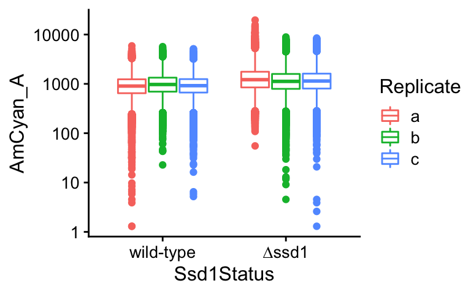

```r
ggplot(data = flow_data_gated %>%
         dplyr::filter(!is.na(MotifCount), MotifCount == 2, Replicate %in% c("a","b","c")),
       aes(x = Ssd1Status, y = AmCyan_A, colour = Replicate)) +
  geom_boxplot() +
  scale_y_log10()
```

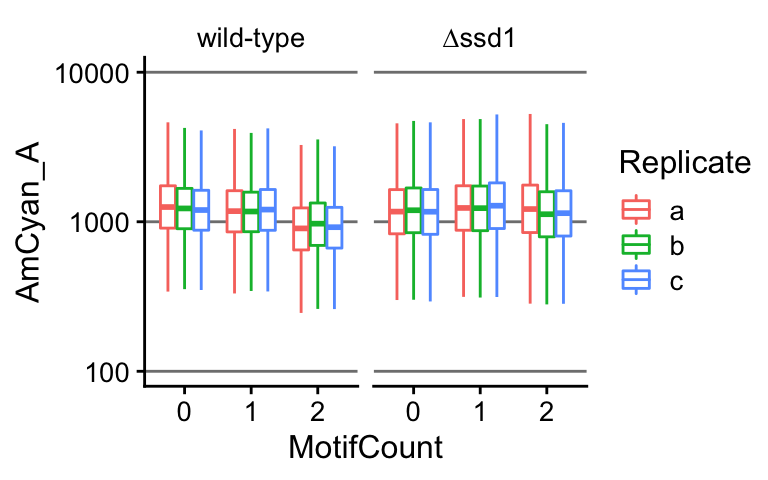

```r
ggplot(data = flow_data_gated %>%
         dplyr::filter(!is.na(MotifCount), Replicate %in% c("a","b","c")),
       aes(x = MotifCount, y = AmCyan_A, colour = Replicate)) +
  geom_boxplot(outlier.color = NA) +
  facet_wrap(~Ssd1Status, nrow = 1) +
  scale_y_log10(limits = c(100,10000)) +
  theme(panel.grid.major.y = element_line(size = 0.5, colour = "grey50"))
```

### Summarise distribution of blue to red ratio

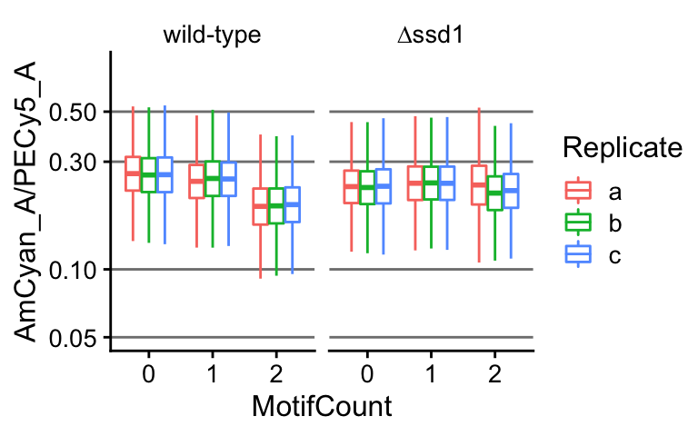

```r
ggplot(data = flow_data_gated %>%
         dplyr::filter(!is.na(MotifCount), Replicate %in% c("a","b","c")),
       aes(x = MotifCount, y = AmCyan_A/PECy5_A , colour = Replicate)) +
  geom_boxplot(outlier.color = NA) +
  facet_wrap(~Ssd1Status, nrow = 1) +
  scale_y_log10(limits = c(0.05,0.8)) +
  theme(panel.grid.major.y = element_line(size = 0.5, colour = "grey50"))
```

### Blue to red ratio shows that Ssd1 motifs repress translation only in wild-type cells

Estimate median blue:red ratio for WT 0 motifs and use to normalise all other ratios. This enables easier visual comparision of how different the ratios are between different samples.

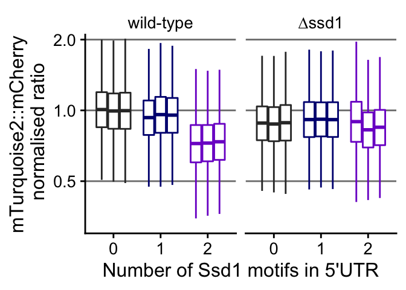

```r
# Estimate median blue:red ratio for WT 0 motifs and use to normalise
medratio_WT_0 <-
  flow_data_gated %>%
         dplyr::filter(Ssd1Status == "wild-type",
                MotifCount == 0,
                Replicate %in% c("a","b","c")) %>%
  mutate(BRratio = AmCyan_A/PECy5_A) %>%
  pull(BRratio) %>%
  median()

ggplot(data = flow_data_gated %>%
         dplyr::filter(!is.na(MotifCount), Replicate %in% c("a","b","c")),
       aes(x = MotifCount,
           y = AmCyan_A/PECy5_A /medratio_WT_0,
           colour = MotifCount,
           group = interaction(MotifCount,Replicate))
       ) +
  geom_boxplot(outlier.color = NA) +
  facet_wrap(~Ssd1Status, nrow = 1) +
  labs(x = "Number of Ssd1 motifs in 5'UTR") +
  scale_colour_manual(values = c("grey20","navy","purple3")) +
  scale_y_log10("mTurquoise2::mCherry\n normalised ratio",
    limits = c(0.3, 2.1), breaks = c(0.25,0.5,1,2,4), expand = c(0,0)) +
  theme(panel.grid.major.y = element_line(size = 0.5, colour = "grey50"),
        legend.position = "none")
```

### Median summaries of key read-outs for each sample

This gives the numbers behind the visualisations above.

```r
flow_data_gated %>%
         dplyr::filter(!is.na(MotifCount), Replicate %in% c("a","b","c")) %>%
  group_by(Ssd1Status,MotifCount) %>%
  summarise(
    FSC_A = median(FSC_A),
    AmCyan_A = median(AmCyan_A),
    PECy5_A  = median(PECy5_A),
    BRratio  = median(AmCyan_A/PECy5_A /medratio_WT_0)
  )
```

```
## # A tibble: 6 × 6
## # Groups:   Ssd1Status [2]
##   Ssd1Status MotifCount  FSC_A AmCyan_A PECy5_A BRratio
##   <fct>      <fct>       <dbl>    <dbl>   <dbl>   <dbl>
## 1 wild-type  0          92830.    1226.   4617.   1.01
## 2 wild-type  1          91150.    1185.   4690.   0.959
## 3 wild-type  2          91019.     931.   4767.   0.741
## 4 ∆ssd1      0          91534.    1176.   5033.   0.887
## 5 ∆ssd1      1          91614.    1250.   5134.   0.924
## 6 ∆ssd1      2          88764.    1159.   5088.   0.865
```

## Linear models show that all relevant differences are highly significant by t-test

```r
fit_Strain_2motifs <-
  lm(log2BR ~ Ssd1Status,
  data =
    flow_data_gated %>%
         dplyr::filter(!is.na(MotifCount),
                       Replicate %in% c("a","b","c"),
                       MotifCount == 2) %>%
    dplyr::mutate(log2BR = log2(AmCyan_A/PECy5_A)) %>%
    dplyr::filter(is.finite(log2BR))
   )
summary(fit_Strain_2motifs)
```

```
##
## Call:
## lm(formula = log2BR ~ Ssd1Status, data = flow_data_gated %>%
##     dplyr::filter(!is.na(MotifCount), Replicate %in% c("a", "b",
##         "c"), MotifCount == 2) %>% dplyr::mutate(log2BR = log2(AmCyan_A/PECy5_A)) %>%
##     dplyr::filter(is.finite(log2BR)))
##
## Residuals:
##     Min      1Q  Median      3Q     Max
## -9.2122 -0.2552  0.0072  0.2662  4.8869
##
## Coefficients:
##                   Estimate Std. Error t value Pr(>|t|)
## (Intercept)     -2.3960702  0.0007202 -3326.9   <2e-16 ***
## Ssd1Status∆ssd1  0.2443502  0.0010192   239.7   <2e-16 ***
## ---
## Signif. codes:  0 '***' 0.001 '**' 0.01 '*' 0.05 '.' 0.1 ' ' 1
##
## Residual standard error: 0.3954 on 601964 degrees of freedom
## Multiple R-squared:  0.08716,    Adjusted R-squared:  0.08715
## F-statistic: 5.747e+04 on 1 and 601964 DF,  p-value: < 2.2e-16
```

```r
fit_Strain_1motifs <-
  lm(log2BR ~ Ssd1Status,
  data =
    flow_data_gated %>%
         dplyr::filter(!is.na(MotifCount),
                       Replicate %in% c("a","b","c"),
                       MotifCount == 1) %>%
    dplyr::mutate(log2BR = log2(AmCyan_A/PECy5_A)) %>%
    dplyr::filter(is.finite(log2BR))
   )
summary(fit_Strain_1motifs)
```

```
##
## Call:
## lm(formula = log2BR ~ Ssd1Status, data = flow_data_gated %>%
##     dplyr::filter(!is.na(MotifCount), Replicate %in% c("a", "b",
##         "c"), MotifCount == 1) %>% dplyr::mutate(log2BR = log2(AmCyan_A/PECy5_A)) %>%
##     dplyr::filter(is.finite(log2BR)))
##
## Residuals:
##     Min      1Q  Median      3Q     Max
## -5.4386 -0.2413  0.0065  0.2514  6.6094
##
## Coefficients:
##                   Estimate Std. Error  t value Pr(>|t|)
## (Intercept)     -2.0082270  0.0006436 -3120.13   <2e-16 ***
## Ssd1Status∆ssd1 -0.0503245  0.0009112   -55.23   <2e-16 ***
## ---
## Signif. codes:  0 '***' 0.001 '**' 0.01 '*' 0.05 '.' 0.1 ' ' 1
##
## Residual standard error: 0.3535 on 602087 degrees of freedom
## Multiple R-squared:  0.00504,    Adjusted R-squared:  0.005039
## F-statistic:  3050 on 1 and 602087 DF,  p-value: < 2.2e-16
```

```r
fit_Strain_0motifs <-
  lm(log2BR ~ Ssd1Status,
  data =
    flow_data_gated %>%
         dplyr::filter(!is.na(MotifCount),
                       Replicate %in% c("a","b","c"),
                       MotifCount == 0) %>%
    dplyr::mutate(log2BR = log2(AmCyan_A/PECy5_A)) %>%
    dplyr::filter(is.finite(log2BR))
   )
summary(fit_Strain_0motifs)
```

```
##
## Call:
## lm(formula = log2BR ~ Ssd1Status, data = flow_data_gated %>%
##     dplyr::filter(!is.na(MotifCount), Replicate %in% c("a", "b",
##         "c"), MotifCount == 0) %>% dplyr::mutate(log2BR = log2(AmCyan_A/PECy5_A)) %>%
##     dplyr::filter(is.finite(log2BR)))
##
## Residuals:
##     Min      1Q  Median      3Q     Max
## -6.7099 -0.2431  0.0061  0.2517  9.7021
##
## Coefficients:
##                   Estimate Std. Error t value Pr(>|t|)
## (Intercept)     -1.9291955  0.0006547 -2946.7   <2e-16 ***
## Ssd1Status∆ssd1 -0.1848073  0.0009266  -199.5   <2e-16 ***
## ---
## Signif. codes:  0 '***' 0.001 '**' 0.01 '*' 0.05 '.' 0.1 ' ' 1
##
## Residual standard error: 0.3594 on 601758 degrees of freedom
## Multiple R-squared:  0.06201,    Adjusted R-squared:  0.06201
## F-statistic: 3.978e+04 on 1 and 601758 DF,  p-value: < 2.2e-16
```

```r
fit_S2motifs_WT <-
  lm(log2BR ~ MotifCount,
  data =
    flow_data_gated %>%
         dplyr::filter(!is.na(MotifCount),
                       Replicate %in% c("a","b","c"),
                       MotifCount %in% c(0,2),
                       Ssd1Status == "wild-type") %>%
    dplyr::mutate(log2BR = log2(AmCyan_A/PECy5_A)) %>%
    dplyr::filter(is.finite(log2BR))
   )
summary(fit_S2motifs_WT)
```

```
##
## Call:
## lm(formula = log2BR ~ MotifCount, data = flow_data_gated %>%
##     dplyr::filter(!is.na(MotifCount), Replicate %in% c("a", "b",
##         "c"), MotifCount %in% c(0, 2), Ssd1Status == "wild-type") %>%
##     dplyr::mutate(log2BR = log2(AmCyan_A/PECy5_A)) %>% dplyr::filter(is.finite(log2BR)))
##
## Residuals:
##     Min      1Q  Median      3Q     Max
## -9.2122 -0.2483  0.0086  0.2622  9.7021
##
## Coefficients:
##               Estimate Std. Error t value Pr(>|t|)
## (Intercept) -1.9291955  0.0006909 -2792.2   <2e-16 ***
## MotifCount2 -0.4668747  0.0009771  -477.8   <2e-16 ***
## ---
## Signif. codes:  0 '***' 0.001 '**' 0.01 '*' 0.05 '.' 0.1 ' ' 1
##
## Residual standard error: 0.3793 on 602740 degrees of freedom
## Multiple R-squared:  0.2747, Adjusted R-squared:  0.2747
## F-statistic: 2.283e+05 on 1 and 602740 DF,  p-value: < 2.2e-16
```

```r
fit_S2motifs_dS <-
  lm(log2BR ~ MotifCount,
  data =
    flow_data_gated %>%
         dplyr::filter(!is.na(MotifCount),
                       Replicate %in% c("a","b","c"),
                       MotifCount %in% c(0,2),
                       Ssd1Status == "∆ssd1") %>%
    dplyr::mutate(log2BR = log2(AmCyan_A/PECy5_A)) %>%
    dplyr::filter(is.finite(log2BR))
   )
summary(fit_S2motifs_dS)
```

```
##
## Call:
## lm(formula = log2BR ~ MotifCount, data = flow_data_gated %>%
##     dplyr::filter(!is.na(MotifCount), Replicate %in% c("a", "b",
##         "c"), MotifCount %in% c(0, 2), Ssd1Status == "∆ssd1") %>%
##     dplyr::mutate(log2BR = log2(AmCyan_A/PECy5_A)) %>% dplyr::filter(is.finite(log2BR)))
##
## Residuals:
##     Min      1Q  Median      3Q     Max
## -8.8629 -0.2500  0.0048  0.2557  9.1010
##
## Coefficients:
##               Estimate Std. Error  t value Pr(>|t|)
## (Intercept) -2.1140029  0.0006866 -3078.73   <2e-16 ***
## MotifCount2 -0.0377172  0.0009709   -38.85   <2e-16 ***
## ---
## Signif. codes:  0 '***' 0.001 '**' 0.01 '*' 0.05 '.' 0.1 ' ' 1
##
## Residual standard error: 0.3764 on 600982 degrees of freedom
## Multiple R-squared:  0.002505,   Adjusted R-squared:  0.002503
## F-statistic:  1509 on 1 and 600982 DF,  p-value: < 2.2e-16
```

## To do

- check the repeated samples look reproducible
- double-check the gating strategy
- subset by cell size and shape (proxy for budded/unbudded)